# Homework 2: Regressions and Intro to Causal Inference

STA 235H

Due on Sep. 22nd, 11:59pm

# Note

- This document will serve as your Answer Key for Homework 2. Please check the rubric to understand how the assignment is graded.
- All automatically-graded questions will receive full credit if correct or 0 points if they are not correct. The only exception is with multiple answers were points are allocated proportionally (with discounts).
- Inconsistencies between code and answers will be discounted (i.e. if an answer is correct, but the code used to get to that answer is not, that question will be discounted).
- Any R scripts and PDF files will also be checked for completeness. If they are not complete (i.e. do not contain the code/output requested), a discount will apply.
- After you receive your graded assignment, you will have one week to submit re-grading requests. Please compare your graded submission with this answer key and fill out the re-grading form with your specific request.

# Task 1 - Introductory Questions for Causal Inference (15 points)

**1.1) Which of the following statements is/are TRUE according to what we saw in class about Causal Inference?** *(4 points)*

1. In social sciences, we can observe individual causal effects in very specific scenarios, like twin studies.
2. To estimate a causal effect, we should just compare the means between the treated and the control group.
3. Treatments are always binary.
4. The fundamental problem of causal inference relates to the fact that we can only observe, at most, only one potential outcome.

*Answer:*

*d)*

**1.2) In the following scenario, identify the treatment variable and all the values it can take:** *(3 points)* *UT is offering a 1-day workshop on R coding for freshmen, which can be taken in person or online, though inscription is voluntary. This workshop is intended to increase the grades for students in quantitative courses.*

*Answer:*

*The treatment variable is the R worskhop attendance, and it can take the values of “in-person”, “online”, or “not take it”*.

1 point per correct value.

1 point discount if doesn’t indicate what the treatment variable is.

(2 points max if “values” are not correct/ confusion with outcome)

**1.3) Identify the potential outcomes in the following example:** *(4 points)* *I made a purchase on this website because I received a promotional email*

*Answer:*

*Whether the person makes a purchase or not if they receive the email or whether the person makes a purchase or not if they don’t receive the email*.

The potential outcomes are two, but it will be considered correct as well if marked all values it can take.

**1.4) Which of the following statements is/are TRUE?** *(4 points)*

1. If our estimates without outliers in our data are significantly different from our estimates obtained with complete data, then we should just drop those outliers.
2. The Linear Probability Model does a good job in prediction, because the interpretation of the coefficients is straightforward.
3. In the linear probability model, we usually interpret coefficients as changes in probability.
4. We can sometimes apply a logarithm to an outcome to make it normally distributed.

*Answer:*

*c and d.*

**1.5) We ran a regression on the revenue of a movie on their budget and the squared of the budget, and obtained the following results:**
$$Revenue = 5.42 +
1.12\times Budget + 0.004 \times Budget^2$$
**where both budget and revenue are measured in millions of dollars. Which of the following statements is/are TRUE?** *(3 points)*

*Answer:*

*The association between revenue and budget is not constant acrsoss the budget distribution.*

# Task 2 - Let’s AirBnB! (50 points)

You are thinking on AirBnB’ing your place out for the summer, so you are currently doing some market research about listing characteristics. As the avid data person that you are, you have managed to get access to the following AirBnB dataset:

```r
airbnb = read.csv("https://raw.githubusercontent.com/maibennett/sta235/main/exampleSite/content/Assignments/Homework/Homework2/data/airbnb_reviews.csv")
```

You can see the codebook for this dataset [here](https://sta235.com/airbnb_codebook)

The goal of this task is to analyze how different listing characteristics relate to nightly price in an AirBnB post.

**2.1) Load your data and look at the values for the different cities. How many cities are there?** *(3 points)*

```r
cities_tab = airbnb %>% select(city) %>% table(.)

cities_tab
```

```
## city
##        Bangkok      Cape Town      Hong Kong       Istanbul    Mexico City
##           9806           9608           3614          12217          10010
##       New York          Paris Rio de Janeiro           Rome         Sydney
##          37014          32206          13404          13584          16901
```

```r
length(cities_tab)
```

```
## [1] 10
```

*10 cities*

**2.2) Now, let’s clean our data. We want to keep observations from listings only in the US, to make it more comparable to our problem (look at the variable `city` for this). Also, we want to make sure that we are not considering any free listings (no nightly price charge), or listings with missing ratings (e.g. `review_scores_rating`). Finally, let’s only focus on short-term rentals (under 30 minimum nights) that are not hotels. How many observations are there now?** *Note: All changes need to be made on the same dataset, `airbnb`.* *(5 points)*

```r
airbnb = airbnb %>% filter(city == "New York" & price>0 & !is.na(review_scores_rating) & minimum_nights<30 & room_type!="Hotel room")

nrow(airbnb)
```

```
## [1] 10093
```

*10093* observations

**2.3) Create a histogram of the logarithm of nightly price. Describe your plot.** *(3 points)*

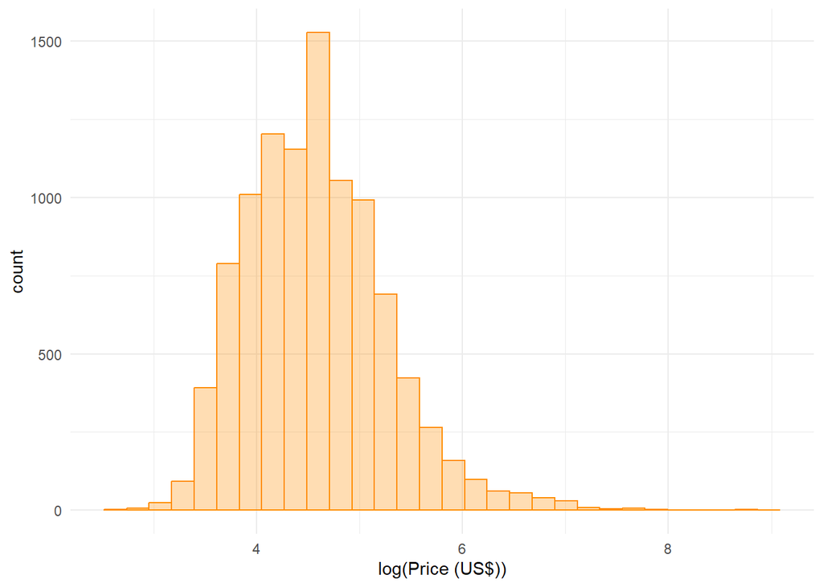

```r
ggplot(data = airbnb, aes(x = log(price))) +
  geom_histogram(color = "darkorange", fill = alpha("darkorange", 0.3)) +
  xlab("log(Price (US$))") + theme_minimal()
```

*The logarithm of price seems to follow a normal distribution, though we can osberve a few outliers in the right tail.*

2 points for the histogram (including correct label like `log(Price)`, `log(Nightly Price)`, etc.)

1 point for explanation (e.g. normal distribution, some outliers/longer right tail)

**2.4a) In the same dataset, create a binary variable called `outlier_price` which takes the value of 1 if the observation has a logarithm of price greater than 8, and 0 in another case. Show your code here:** *(3 points)*

*Answer:*

```r
airbnb = airbnb %>% mutate(outlier_price = ifelse(log(price)>8, 1, 0))
```

3 points for correct code

0 otherwise

**2.4b) According to your previous code, how many outliers do you have?** *(2 points)*

```r
airbnb %>% select(outlier_price) %>% table(.)
```

```
## outlier_price
##     0     1
## 10088     5
```

*5 outliers*

**2.5) Using your entire clean dataset, fit a linear model for the logarithm of price, using rating score, number of reviews, minimum nights for a stay, number of people it accommodates, and room type. Interpret the association between the outcome and the number of minimum nights.** *(5 points)*

```r
lm_price = lm(log(price) ~ review_scores_rating + num_reviews + minimum_nights + accommodates + room_type, data = airbnb)

summary(lm_price)
```

```
##
## Call:
## lm(formula = log(price) ~ review_scores_rating + num_reviews +
##     minimum_nights + accommodates + room_type, data = airbnb)
##
## Residuals:
##     Min      1Q  Median      3Q     Max
## -2.0206 -0.3261 -0.0563  0.2663  4.9260
##
## Coefficients:
##                          Estimate  Std. Error t value             Pr(>|t|)
## (Intercept)            3.84696255  0.05823530  66.059 < 0.0000000000000002 ***
## review_scores_rating   0.00666234  0.00058928  11.306 < 0.0000000000000002 ***
## num_reviews           -0.00062370  0.00007577  -8.231 < 0.0000000000000002 ***
## minimum_nights        -0.00506572  0.00125154  -4.048            0.0000521 ***
## accommodates           0.13008581  0.00267034  48.715 < 0.0000000000000002 ***
## room_typePrivate room -0.51993738  0.01144466 -45.431 < 0.0000000000000002 ***
## room_typeShared room  -0.80143132  0.03584650 -22.357 < 0.0000000000000002 ***
## ---
## Signif. codes:  0 '***' 0.001 '**' 0.01 '*' 0.05 '.' 0.1 ' ' 1
##
## Residual standard error: 0.4955 on 10086 degrees of freedom
## Multiple R-squared:  0.4737, Adjusted R-squared:  0.4734
## F-statistic:  1513 on 6 and 10086 DF,  p-value: < 0.00000000000000022
```

*On average, increasing the minimum night stay by one night is associated with a 0.51% decrease is nightly price, holding other variables in the model constant.*

1 point for correct estimate

1 point for correct units (%)

1 point for “on average” (“expected” is not the same, but allowed)

1 point for “increasing min nights by one night” or similar

1 point for “holding other variables constant”

**2.6) Using the same model as before, now run this regression on your data without outliers. Is there a qualitatively significant change in your previous estimate?** *Note: You can create a new dataset for this. For the purpose of this question, let’s assume a significant change in magnitude is a 20% change with respect to the original estimate.* *(5 points)*

```r
airbnb_no_outliers = airbnb %>% filter(outlier_price==0)

lm_price_no = lm(log(price) ~ review_scores_rating + num_reviews + minimum_nights + accommodates + room_type, data = airbnb_no_outliers)

summary(lm_price_no)
```

```
##
## Call:
## lm(formula = log(price) ~ review_scores_rating + num_reviews +
##     minimum_nights + accommodates + room_type, data = airbnb_no_outliers)
##
## Residuals:
##     Min      1Q  Median      3Q     Max
## -2.0196 -0.3252 -0.0543  0.2675  3.1145
##
## Coefficients:
##                          Estimate  Std. Error t value             Pr(>|t|)
## (Intercept)            3.83582194  0.05734323  66.892 < 0.0000000000000002 ***
## review_scores_rating   0.00684345  0.00058047  11.790 < 0.0000000000000002 ***
## num_reviews           -0.00069743  0.00007483  -9.320 < 0.0000000000000002 ***
## minimum_nights        -0.00527483  0.00123207  -4.281            0.0000188 ***
## accommodates           0.12929351  0.00263691  49.032 < 0.0000000000000002 ***
## room_typePrivate room -0.52263500  0.01127553 -46.351 < 0.0000000000000002 ***
## room_typeShared room  -0.80213198  0.03528910 -22.730 < 0.0000000000000002 ***
## ---
## Signif. codes:  0 '***' 0.001 '**' 0.01 '*' 0.05 '.' 0.1 ' ' 1
##
## Residual standard error: 0.4878 on 10081 degrees of freedom
## Multiple R-squared:  0.4815, Adjusted R-squared:  0.4812
## F-statistic:  1560 on 6 and 10081 DF,  p-value: < 0.00000000000000022
```

1. Yes
2. No
3. We can’t say. It depends on the level of number of nights we are starting at.

*Answer:*

*No*

**2.7) You think there might be a quadratic association between your outcome and number of reviews. Create a scatter plot between logarithm of price and number of reviews. Include a regression line for a simple linear model and a quadratic model, as seen in class.** *Note: Include a legend to distinguish both lines (you can find some helpful code on the R script provided for Week 3 (line 99 onwards))*. *(8 points)*

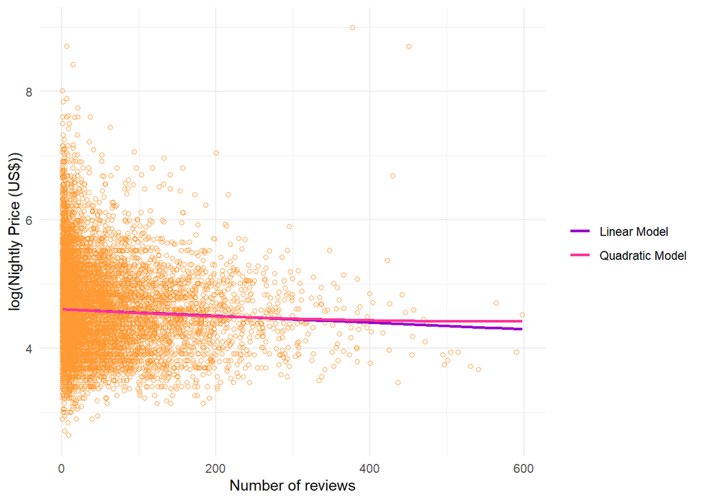

```r
ggplot(data = airbnb, aes(y = log(price), x = num_reviews)) +
  geom_point(pch = 1, color = "#ff9933", fill = alpha("#ff9933", 0.3)) +
  geom_smooth(aes(color = "Linear Model"), method = "lm", se = FALSE) +
  geom_smooth(aes(color = "Quadratic Model"), method = "lm", formula = y ~ x + I(x^2), se = FALSE) +
  scale_color_manual(labels = c("Linear Model", "Quadratic Model"), values = c("#9900cc", "#ff3399"), name = "") +
  theme_minimal() + xlab("Number of reviews") + ylab("log(Nightly Price (US$))")
```

5 points for correct code for scatter plot and two geom_smooth() lines

3 points for correct plot (including axis labels and legend)

**2.8) What is the average increase in price if we increase the number of reviews for 1 to 2? And from 500 to 501? Provide the estimates for both the linear model in 2.4, as well as the same model, but now including a quadratic polynomial term for number of reviews.** *Note: Round your answers to 2 decimal places. Include the units for your estimates.* *(8 points)*

*Answer:*

```r
lm_price2 = lm(log(price) ~ review_scores_rating + num_reviews + I(num_reviews^2) + minimum_nights + accommodates + room_type, data = airbnb)

summary(lm_price2)
```

```
##
## Call:
## lm(formula = log(price) ~ review_scores_rating + num_reviews +
##     I(num_reviews^2) + minimum_nights + accommodates + room_type,
##     data = airbnb)
##
## Residuals:
##     Min      1Q  Median      3Q     Max
## -2.0206 -0.3244 -0.0545  0.2616  4.6727
##
## Coefficients:
##                            Estimate    Std. Error t value             Pr(>|t|)
## (Intercept)            3.8461164874  0.0581232926  66.172 < 0.0000000000000002
## review_scores_rating   0.0068897047  0.0005892403  11.693 < 0.0000000000000002
## num_reviews           -0.0015481814  0.0001646390  -9.403 < 0.0000000000000002
## I(num_reviews^2)       0.0000034969  0.0000005532   6.322        0.00000000027
## minimum_nights        -0.0054248107  0.0012504225  -4.338        0.00001449325
## accommodates           0.1305749427  0.0026663238  48.972 < 0.0000000000000002
## room_typePrivate room -0.5213583920  0.0114248335 -45.634 < 0.0000000000000002
## room_typeShared room  -0.8009627337  0.0357775384 -22.387 < 0.0000000000000002
##
## (Intercept)           ***
## review_scores_rating  ***
## num_reviews           ***
## I(num_reviews^2)      ***
## minimum_nights        ***
## accommodates          ***
## room_typePrivate room ***
## room_typeShared room  ***
## ---
## Signif. codes:  0 '***' 0.001 '**' 0.01 '*' 0.05 '.' 0.1 ' ' 1
##
## Residual standard error: 0.4946 on 10085 degrees of freedom
## Multiple R-squared:  0.4758, Adjusted R-squared:  0.4754
## F-statistic:  1308 on 7 and 10085 DF,  p-value: < 0.00000000000000022
```

For the linear model, the change in price is: $= $ -0.001$\times 100$%, and is the same for a one-unit increase at any point.

For the quadratic model, the change in price is: $\Delta = (\hat{\beta}_{NR} + 2\times \hat{\beta}_{NR^2} \times NumRev_0)\times 100$%.

Linear model increase from 1 to 2 reviews: -0.06%

Linear model increase from 500 to 501 reviews: -0.06%

Quadratic model increase from 1 to 2 reviews: -0.15%

Quadratic model increase from 1 to 2 reviews: 0.19%

2 points each

**2.9) Using the previous quadratic model, interpret the association between number of reviews and price, when increasing the number of reviews from 500 to 501.** *(5 points)*

Increasing the number of reviews from 500 to 501 is associated with an average increase in price of 0.19%, holding other variables constant.

1 point for correct estimate

1 point for correct units (%)

1 point for “on average” (“expected” is not the same, but allowed)

1 point for “increasing from 500 to 501 reviews” or similar

1 point for “holding other variables constant”

# Task 3 - Getting those deposits in (35 points)

In this task, you are asked to work with the marketing team from a bank. They have recently launched a new campaign, and want to analyze the effectiveness of their efforts. Specifically, they are interested in analyzing what characteristics are associated with a successful outcome, which they determine as a client making a term deposit.

You can find the data for the bank here:

```r
bank = read.csv("https://raw.githubusercontent.com/maibennett/sta235/main/exampleSite/content/Assignments/Homework/Homework2/data/bank.csv")
```

And a description for the variables in the following [codebook]((https://sta235.com/bank_codebook)

**3.1) Transform the variable balance into thousands of dollars, and transform the variable `deposit` into a binary (numeric) variable. How many customers have made a term deposit? How many people have a 0 balance in their account or less?** *(5 points)*

```r
bank = bank %>% mutate(balance = balance/1000,
                       deposit = ifelse(deposit == "yes", 1, 0),)

bank %>% select(deposit) %>% table()
```

```
## deposit
##    0    1
## 5873 5289
```

```r
bank %>% filter(balance<=0) %>% nrow()
```

```
## [1] 1462
```

2.5 points for each correct number

**3.2) Fit a linear model on the outcome of interest, using age, whether someone has tertiary education or not (`tertiary_educ`), balance, default, whether the person has any type of loan (`any_loan`), and campaign as covariates. Show your code here:** *(Note: Include the code for creating the missing variables and for the model)* *(5 points)*

```r
bank = bank %>% mutate(tertiary_educ = ifelse(education == "tertiary", 1, 0),
                       any_loan = ifelse(loan == "yes" | housing == "yes", 1, 0))

library(estimatr)
options(scipen = 0)

lpm_dep = lm_robust(deposit ~ age + tertiary_educ + balance + default + any_loan + campaign, data = bank)

summary(lpm_dep)
```

```
##
## Call:
## lm_robust(formula = deposit ~ age + tertiary_educ + balance +
##     default + any_loan + campaign, data = bank)
##
## Standard error type:  HC2
##
## Coefficients:
##                 Estimate Std. Error  t value   Pr(>|t|)   CI Lower   CI Upper
## (Intercept)    6.139e-01  0.0193331  31.7525 6.625e-212  0.5759793  0.6517720
## age           -7.817e-05  0.0003857  -0.2027  8.394e-01 -0.0008341  0.0006778
## tertiary_educ  6.620e-02  0.0098978   6.6882  2.367e-11  0.0467973  0.0856003
## balance        8.150e-03  0.0015999   5.0938  3.567e-07  0.0050134  0.0112856
## defaultyes    -9.357e-02  0.0364661  -2.5659  1.030e-02 -0.1650486 -0.0220885
## any_loan      -2.151e-01  0.0094207 -22.8322 8.270e-113 -0.2335622 -0.1966296
## campaign      -2.230e-02  0.0017117 -13.0262  1.658e-38 -0.0256516 -0.0189413
##                  DF
## (Intercept)   11155
## age           11155
## tertiary_educ 11155
## balance       11155
## defaultyes    11155
## any_loan      11155
## campaign      11155
##
## Multiple R-squared:  0.07642 ,   Adjusted R-squared:  0.07592
## F-statistic:   157 on 6 and 11155 DF,  p-value: < 2.2e-16
```

2 points for creating the variables correctly (`tertiary_educ` and `any_loan`)

2 points for using lm_robust()

1 point for running the correct model (correct outcome and covariates)

–1 point if names of variables is not correct

**3.3) Using the previous model, interpret the coefficient for `any_loan`** *(5 points)*

On average, having a personal or housing loan vs not a loan is associated with an increase of -21.5 percentage points in the probability of making a term deposit, holding other variables constant.

1 point for correct estimate

1 point for correct units (change in probability/percentage points)

1 point for “on average” (“expected” is not the same, but allowed)

1 point for “having any loan vs not having a loan” or similar

1 point for “holding other variables constant”

**3.4) Using the previous model, interpret the coefficient for `age`** *(5 points)*

On average, one additional year of age is associated with a -0.008 percentage point increase in the probability of making a deposit, holding other variables constant. However, this association is not statistically significant at conventional levels.

1 point for correct estimate (don’t discount again if estimate was incorrect in 3.3)

1 point for correct units (change in probability/percentage points)

1 point for “on average” (“expected” is not the same, but allowed)

1 point for “one additional year of age” and “holding other variables constant”

1 point for mentioning the association is not statistically significant.

**3.5) You think that balance is a relevant variable in your model, as people who have larger balances in their account might be more likely to make a deposit. A colleague suggests that the impact of this variable might be different for people who have a loan from people that don’t. How would you test this? Write the code for your model:** *(5 points)*

```r
lpm_inter = lm_robust(deposit ~ age + default + campaign + tertiary_educ + any_loan*balance, data = bank)

summary(lpm_inter)
```

```
##
## Call:
## lm_robust(formula = deposit ~ age + default + campaign + tertiary_educ +
##     any_loan * balance, data = bank)
##
## Standard error type:  HC2
##
## Coefficients:
##                    Estimate Std. Error  t value   Pr(>|t|)  CI Lower   CI Upper
## (Intercept)       6.143e-01  0.0193901  31.6803 5.434e-211  0.576278  0.6522939
## age              -7.808e-05  0.0003857  -0.2025  8.396e-01 -0.000834  0.0006779
## defaultyes       -9.327e-02  0.0365069  -2.5549  1.064e-02 -0.164831 -0.0217111
## campaign         -2.229e-02  0.0017113 -13.0263  1.654e-38 -0.025647 -0.0189380
## tertiary_educ     6.612e-02  0.0098957   6.6818  2.472e-11  0.046724  0.0855191
## any_loan         -2.160e-01  0.0105166 -20.5410  4.627e-92 -0.236635 -0.1954066
## balance           7.937e-03  0.0019494   4.0718  4.698e-05  0.004116  0.0117585
## any_loan:balance  6.328e-04  0.0033763   0.1874  8.513e-01 -0.005985  0.0072509
##                     DF
## (Intercept)      11154
## age              11154
## defaultyes       11154
## campaign         11154
## tertiary_educ    11154
## any_loan         11154
## balance          11154
## any_loan:balance 11154
##
## Multiple R-squared:  0.07642 ,   Adjusted R-squared:  0.07584
## F-statistic: 134.7 on 7 and 11154 DF,  p-value: < 2.2e-16
```

2 points for `using lm_robust()`

3 points for the correct model (right outcome, correct covariates, and the interaction)

**3.6) Interpret the association between `balance` and `deposit` for customers that have a loan:** *(5 points)*

On average, for customers that have a loan, a $1,000 increase in their balance is associated with a 0.86 percentage point increase in the probability of making a deposit.

1 point for correct estimate

1 point for correct units (change in probability/percentage points)

1 point for “on average” (“expected” is not the same, but allowed)

1 point for “a $1,000 increase in balance”

1 point for “holding other variables constant”

**3.7) What is the intercept capturing in this case? Interpret this coefficient.** *(5 points)*

For customers who are 0 years old, do not have tertiary education, have 0 balance, have not defaulted on a loan, do not have a personal or housing loan, and did not receive a campaign call, the average probability of making a deposit is 61.43%

1 point for correct estimate (don’t discount again if estimate was incorrect in 3.6)

2 points for mentioning variables = 0 (explaining what they are).

2 points for interpreting as “average probability” (either in percent or unit-less)